# CUNY DATA 621 - Business Analytics and Data Mining

Blog 3 - Regression using Neural Nets and Keras in R

Walt Wells, 2018

# The Keras Package

The [Keras package](https://tensorflow.rstudio.com/keras/) is a wonderful library that leverages [Keras](https://keras.io/) to let a user build deep learning networks very easily in R. The Keras package is designed to be a user-friendly interface and support backends like Tensorflow, Caffe, or Lasagne for doing deep learning with a variety of hardware including GPUS or TPUS.

It can be used seamlessly with the [CLoudML package](https://tensorflow.rstudio.com/tools/cloudml/articles/getting_started.html) to submit jobs directly to Google Compute Engine’s CloudML API, making it even easier to train deep learning models without the fuss of managing the VMs/hardware.

## Regression using Deep Learning

Deep learning excels at unlocking the secrets of datasets when confronted with large datasets for images, time-series, audio, video, etc. However - it can also be used for regression!

Below we’ll build a very simple 3 layer neural network to make predictions over the popular Boston dataset being used in HW3.

The code here is inspired by chapter 4 in the excellent [Deep Learning with R](https://www.manning.com/books/deep-learning-with-r) book that was published in Jan 2018.

## Environment and Data Prep, Basic EDA

Here we’ll load our data (it comes with the Keras package already split into train and test) and use the DataExplorer package to plot our predictors against our targets.

We’ll also use the mean and sd from the training data to center and scale our training and test datasets.

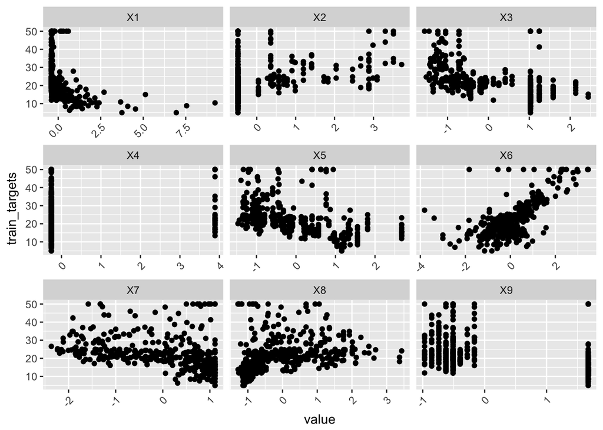

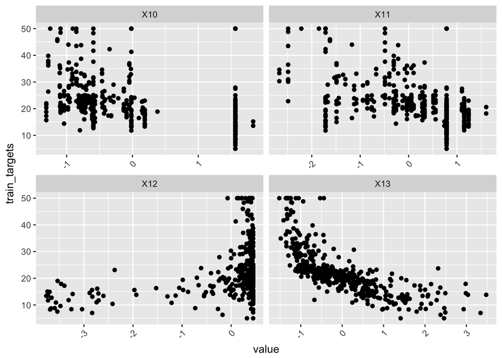

```r
if (!require('keras')) install.packages('keras')
if (!require('DataExplorer')) install.packages('DataExplorer')

boston <- dataset_boston_housing()
c(c(train_data, train_targets), c(test_data, test_targets)) %<-% boston

#normalize data
mean <- apply(train_data, 2, mean)
std <- apply (train_data, 2, sd)
train_data <- scale(train_data, center=mean, scale=std)
test_data <- scale(test_data, center=mean, scale=std)

all_train <- data.frame(train_data, train_targets)
plot_scatterplot(all_train, "train_targets")
```

## Initialize our Network

While it will be out of scope for this blog to discuss some of the nuances of neural network architecture, you can get a sense of just how easy it is to build and train one using keras by seeing the code below.

Here we initialize our architecture as a 3 layer network that takes our train_data as in input shape, has 64 units in each of the first two filters and uses the very simply ReLU function for activating each of the two networks. In the last layer, we output a single value, and that will be our linear regression predictor.

The keras library leverages the magritte/dplyr hadleyverse pipe function to easily add elements to the network. We see in the compile step, we choose our optimizer for backpropogation training, and choose our metrics for loss. Since we’re doing regression, we’ll use MSE and MAE for training and adjudication respectively.

Finally, in the last block we see the our training data actually being piped into our model and the model being fit. We feed in our train_data, ask the network to minimize MSE based on the train_targets, and use our test data to validate. Normally, we would want to have a separate validation dataset, but since there are so few observations here (506 in total), we’ll just use our test to compare. Since deep learning models can easily overfit the training data, it’s important to compare to a validation set so we can see how badly we’re overfitting. Techiniques like regularization or dropout can help mitigate the effects of model overfitting. Since this is a baby regression problem, we’ll not add those layers to our network architecture.

We’ll train for 10 epochs and a batch will be a single row/observation.

```r
model <- keras_model_sequential() %>%
    layer_dense(units = 64, activation = "relu",
                input_shape = 13) %>%
    layer_dense(units = 64, activation = "relu") %>%
    layer_dense(units = 1)

model %>% compile(
    optimizer = "rmsprop",
    loss = "mse",
    metrics = c("mae")
)

summary(model)
```

```
## ___________________________________________________________________________
## Layer (type)                     Output Shape                  Param #
## ===========================================================================
## dense_1 (Dense)                  (None, 64)                    896
## ___________________________________________________________________________
## dense_2 (Dense)                  (None, 64)                    4160
## ___________________________________________________________________________
## dense_3 (Dense)                  (None, 1)                     65
## ===========================================================================
## Total params: 5,121
## Trainable params: 5,121
## Non-trainable params: 0
## ___________________________________________________________________________
```

```r
history <- model %>% fit(
    train_data,
    train_targets,
    validation_data = list(test_data, test_targets),
    epochs = 10,
    batch = 1,
    verbose = 1
)
```

### Training Results

We’ll take a look at the training history we created above by piping our model fit into a variable called “history”. We can then easily plot this to see our given metrics over each epoch. This can be particularly helpful to see where overfit starts.

```r
history
```

```
## Trained on 404 samples, validated on 102 samples (batch_size=1, epochs=10)
## Final epoch (plot to see history):
## val_mean_absolute_error: 2.779
##                val_loss: 19.46
##     mean_absolute_error: 2.179
##                    loss: 10.77
```

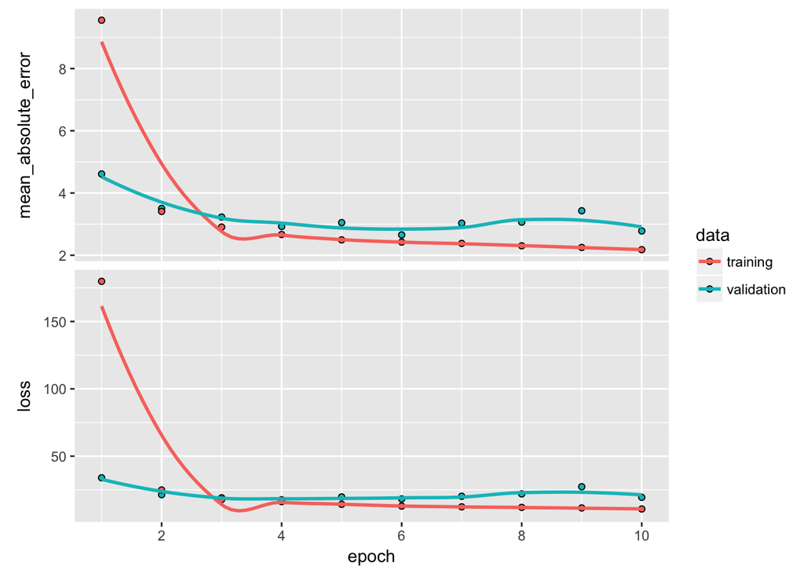

```r
plot(history)
```

We’ll evaluate our final model using the test dataset, and then make some predictions. The final output below shows the first few rows of our predictions over the test data compared to the actual.

```r
evaluate(model, test_data, test_targets)
```

```
## $loss
## [1] 19.45873
##
## $mean_absolute_error
## [1] 2.779352
```

```r
preds <- predict(model, test_data)
final <- data.frame(preds=preds, actual=test_targets)

knitr::kable(head(final))
```

| preds | actual |
| --- | --- |
| 6.201419 | 7.2 |
| 17.672823 | 18.8 |
| 20.568319 | 19.0 |
| 29.410059 | 27.0 |
| 23.549448 | 22.2 |
| 18.953280 | 24.5 |

## Conclusion

While using a neural network to do regression isn’t necessary on smaller datasets like the Boston dataset, the above should serve as an example to start demystifying deep learning and provide context for the excellent new advances the Rstudio teams are rolling out.